# “Análisis de la Supervivencia en el Titanic: El Impacto del Género y la Edad”

Un Estudio Estadístico Descriptivo de los Patrones de Supervivencia

Anyimar Castillo y Gabriel Gonzalez

2025-10-23

```r
knitr::opts_chunk$set(echo = TRUE, warning = FALSE, message = FALSE)
```

# Introduccion

El Titanic, el barco más lujoso de su época, se hundió en su viaje inaugural desde Southampton a Nueva York. La noche del 14 de abril de 1912, chocó contra un iceberg en el Atlántico Norte. En apenas unas horas, la nave se partió y se hundió en las heladas aguas. De las aproximadamente 2,224 personas a bordo, más de 1,500 perdieron la vida, en una de las mayores tragedias marítima. La escasez de botes salvavidas, insuficientes para todos los pasajeros, fue un factor crucial en la alta mortalidad. Existió un protocolo no escrito de “mujeres y niños primero”, pero si este se aplicó de manera efectiva es una de las preguntas clave que busca responder esta investigación. La tragedia conmocionó al mundo y provocó una revisión total de los reglamentos de seguridad marítima. Su legado perdura en la cultura popular, simbolizando los límites de la tecnología frente a la naturaleza.

# Planteamiento de la Investigación

## 1. Planteamiento del Problema

El naufragio del Titanic reveló importantes discrepancias en los protocolos de salvamento, donde factores como el género y la edad pudieron influir en las oportunidades de supervivencia. Por ejemplo, existió la política de “mujeres y niños primero”, a partir de una muestra representativa de pasajeros, esta investigación busca responder preguntas cruciales como: ¿Realmente se privilegió la supervivencia femenina sobre la masculina? ¿Los niños y adultos mayores tuvieron prioridad real en el rescate? ¿Cómo se distribuyeron las edades entre supervivientes y no supervivientes? ¿Existieron diferencias significativas en la composición demográfica entre ambos grupos?

Este estudio se centra exclusivamente en analizar la relación entre variables sexo y edad con la supervivencia en el hundimiento del Titanic. Mediante análisis estadístico descriptivo y comparativo, se examinarán los patrones de supervivencia desagregados por género y grupos etarios, con el objetivo de determinar si existió un perfil demográfico característico entre los sobrevivientes.

La investigación aportará evidencia concreta sobre la aplicación real de los protocolos de salvamento y el papel que jugaron el género y la edad como factores determinantes en la supervivencia durante una de las mayores tragedias marítimas de la historia.

## 2. Objetivo

### 2.1 Objetivo General

Analizar la influencia del sexo y la edad en la supervivencia de los pasajeros del Titanic.

### 2.2 Objetivo Especifico

- Determinar la tasa de supervivencia global por sexo (hombres vs. mujeres).
- Identificar la distribución de edades entre supervivientes y no supervivientes.
- Clasificar a los pasajeros en rangos etarios (niños, adultos, adultos mayores) y evaluar su supervivencia.
- Establecer si existió un patrón de preferencia por algún grupo demográfico (mujeres y niños).

## 3. Justificación

El análisis de sexo y edad en contextos de desastre es crucial para entender las dinámicas sociales y los sesgos en protocolos de emergencia. En el caso del Titanic, este enfoque permite verificar la aplicación real de la norma no escrita de “mujeres y niños primero”. Desde una perspectiva formativa, trabajar con estas variables ofrece una base clara para practicar análisis univariantes y bivariantes, útiles en estadística descriptiva y ciencias sociales.

## 4. Gráficas

```r
# Análisis de supervivencia global
superv_global <- df %>%
  count(Sobrevivio) %>%
  mutate(Porcentaje = round(n/sum(n)*100, 2))

cat("Distribución de Supervivencia Global:\n")
```

```
## Distribución de Supervivencia Global:
```

```r
superv_global %>% kable() %>% kable_styling()
```

| Sobrevivio | n | Porcentaje |
| --- | --- | --- |
| No | 549 | 61.62 |
| Sí | 342 | 38.38 |

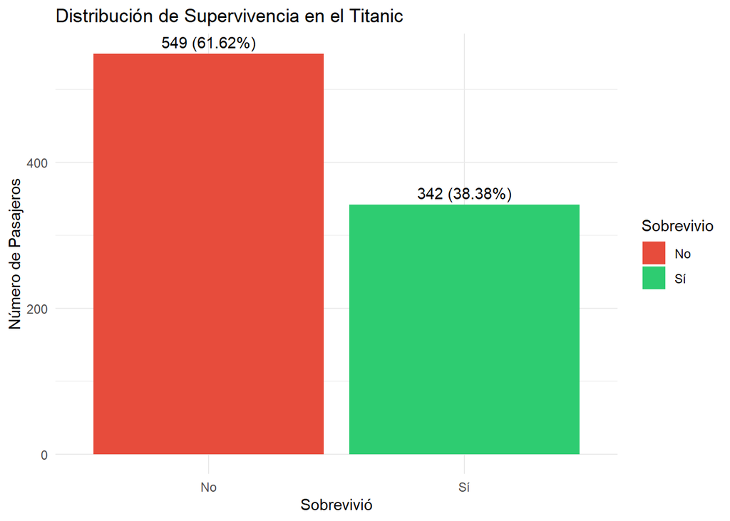

```r
# Gráfico de supervivencia global
ggplot(superv_global, aes(x = Sobrevivio, y = n, fill = Sobrevivio)) +
  geom_bar(stat = "identity") +
  geom_text(aes(label = paste0(n, " (", Porcentaje, "%)")), vjust = -0.5) +
  labs(title = "Distribución de Supervivencia en el Titanic",
       x = "Sobrevivió", y = "Número de Pasajeros") +
  theme_minimal() +
  scale_fill_manual(values = c("No" = "#e74c3c", "Sí" = "#2ecc71"))
```

```r
# Análisis de distribución por sexo
dist_sexo <- df %>%
  count(Sexo) %>%
  mutate(Porcentaje = round(n/sum(n)*100, 2))

cat("Distribución por Sexo:\n")
```

```
## Distribución por Sexo:
```

```r
dist_sexo %>% kable() %>% kable_styling()
```

| Sexo | n | Porcentaje |
| --- | --- | --- |
| Hombre | 577 | 64.76 |
| Mujer | 314 | 35.24 |

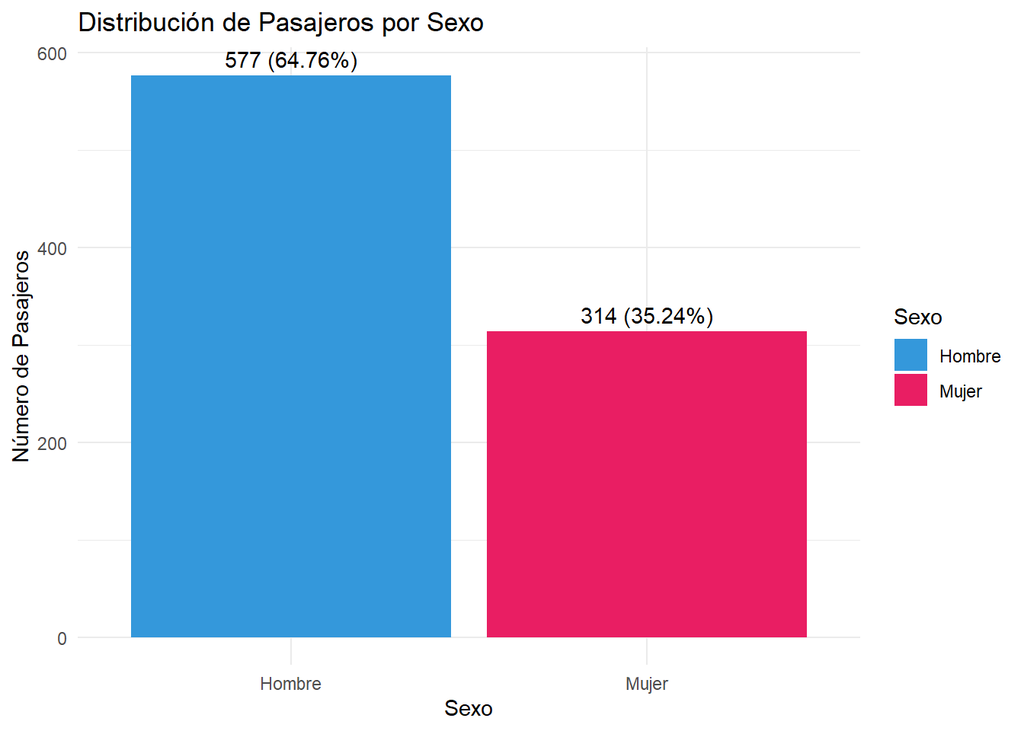

```r
# Gráfico de distribución por sexo
ggplot(dist_sexo, aes(x = Sexo, y = n, fill = Sexo)) +
  geom_bar(stat = "identity") +
  geom_text(aes(label = paste0(n, " (", Porcentaje, "%)")), vjust = -0.5) +
  labs(title = "Distribución de Pasajeros por Sexo",
       x = "Sexo", y = "Número de Pasajeros") +
  theme_minimal() +
  scale_fill_manual(values = c("Hombre" = "#3498db", "Mujer" = "#e91e63"))
```

```r
# Tabla de contingencia: Supervivencia vs Sexo
tabla_sexo <- table(df$Sexo, df$Sobrevivio)
prop_sexo <- prop.table(tabla_sexo, margin = 1) * 100

cat("Tabla de Contingencia: Supervivencia por Sexo\n")
```

```
## Tabla de Contingencia: Supervivencia por Sexo
```

```r
tabla_sexo %>% kable() %>% kable_styling()
```

|  | No | Sí |
| --- | --- | --- |
| Hombre | 468 | 109 |
| Mujer | 81 | 233 |

```r
cat("\nPorcentajes por Fila (Sexo):\n")
```

```
##
## Porcentajes por Fila (Sexo):
```

```r
prop_sexo %>% round(2) %>% kable() %>% kable_styling()
```

|  | No | Sí |
| --- | --- | --- |
| Hombre | 81.11 | 18.89 |
| Mujer | 25.80 | 74.20 |

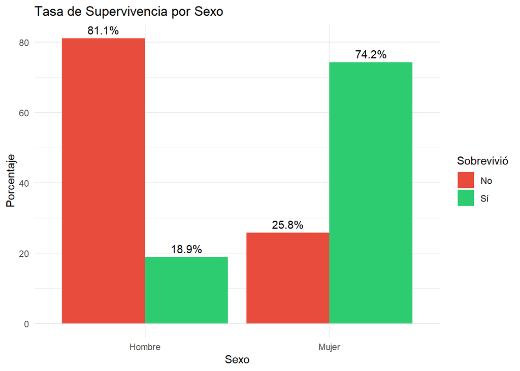

```r
# Gráfico de supervivencia por sexo
df %>%
  count(Sexo, Sobrevivio) %>%
  group_by(Sexo) %>%
  mutate(Porcentaje = n/sum(n)*100) %>%
  ggplot(aes(x = Sexo, y = Porcentaje, fill = Sobrevivio)) +
  geom_bar(stat = "identity", position = "dodge") +
  geom_text(aes(label = paste0(round(Porcentaje, 1), "%")),
            position = position_dodge(width = 0.9), vjust = -0.5) +
  labs(title = "Tasa de Supervivencia por Sexo",
       x = "Sexo", y = "Porcentaje", fill = "Sobrevivió") +
  theme_minimal() +
  scale_fill_manual(values = c("No" = "#e74c3c", "Sí" = "#2ecc71"))
```

```r
# Tabla de contingencia: Supervivencia vs Grupo de Edad
tabla_edad <- table(df$Grupo_Edad, df$Sobrevivio)
prop_edad <- prop.table(tabla_edad, margin = 1) * 100

cat("Tabla de Contingencia: Supervivencia por Grupo de Edad\n")
```

```
## Tabla de Contingencia: Supervivencia por Grupo de Edad
```

```r
tabla_edad %>% kable() %>% kable_styling()
```

|  | No | Sí |
| --- | --- | --- |
| Niño (0-11) | 29 | 39 |
| Adolescente (12-17) | 23 | 22 |
| Adulto (18-59) | 353 | 222 |
| Adulto Mayor (60+) | 19 | 7 |
| Edad Desconocida | 125 | 52 |

```r
cat("\nPorcentajes por Fila (Grupo de Edad):\n")
```

```
##
## Porcentajes por Fila (Grupo de Edad):
```

```r
prop_edad %>% round(2) %>% kable() %>% kable_styling()
```

|  | No | Sí |
| --- | --- | --- |
| Niño (0-11) | 42.65 | 57.35 |
| Adolescente (12-17) | 51.11 | 48.89 |
| Adulto (18-59) | 61.39 | 38.61 |
| Adulto Mayor (60+) | 73.08 | 26.92 |
| Edad Desconocida | 70.62 | 29.38 |

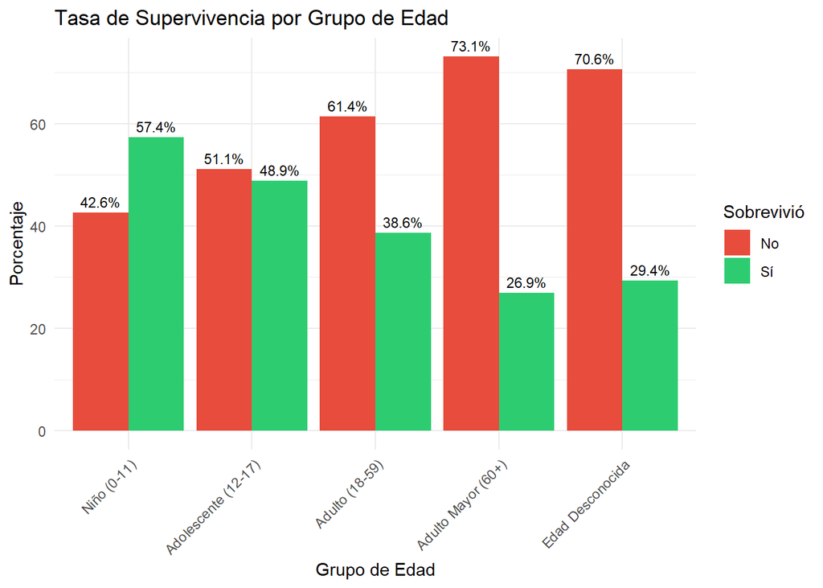

```r
# Gráfico de supervivencia por grupos etarios
df %>%
  count(Grupo_Edad, Sobrevivio) %>%
  group_by(Grupo_Edad) %>%
  mutate(Porcentaje = n/sum(n)*100) %>%
  ggplot(aes(x = Grupo_Edad, y = Porcentaje, fill = Sobrevivio)) +
  geom_bar(stat = "identity", position = "dodge") +
  geom_text(aes(label = paste0(round(Porcentaje, 1), "%")),
            position = position_dodge(width = 0.9), vjust = -0.5, size = 3) +
  labs(title = "Tasa de Supervivencia por Grupo de Edad",
       x = "Grupo de Edad", y = "Porcentaje", fill = "Sobrevivió") +
  theme_minimal() +
  theme(axis.text.x = element_text(angle = 45, hjust = 1)) +
  scale_fill_manual(values = c("No" = "#e74c3c", "Sí" = "#2ecc71"))
```

```r
# Análisis combinado de sexo y grupos etarios
analisis_combinado <- df %>%
  group_by(Sexo, Grupo_Edad) %>%
  summarise(
    Total = n(),
    Sobrevivientes = sum(Sobrevivio == "Sí"),
    Tasa_Supervivencia = round(Sobrevivientes/Total * 100, 2),
    .groups = 'drop'
  )

cat("Análisis Combinado: Sexo y Grupo de Edad\n")
```

```
## Análisis Combinado: Sexo y Grupo de Edad
```

```r
analisis_combinado %>% kable() %>% kable_styling()
```

| Sexo | Grupo_Edad | Total | Sobrevivientes | Tasa_Supervivencia |
| --- | --- | --- | --- | --- |
| Hombre | Niño (0-11) | 36 | 20 | 55.56 |
| Hombre | Adolescente (12-17) | 22 | 3 | 13.64 |
| Hombre | Adulto (18-59) | 373 | 67 | 17.96 |
| Hombre | Adulto Mayor (60+) | 22 | 3 | 13.64 |
| Hombre | Edad Desconocida | 124 | 16 | 12.90 |
| Mujer | Niño (0-11) | 32 | 19 | 59.38 |
| Mujer | Adolescente (12-17) | 23 | 19 | 82.61 |
| Mujer | Adulto (18-59) | 202 | 155 | 76.73 |
| Mujer | Adulto Mayor (60+) | 4 | 4 | 100.00 |
| Mujer | Edad Desconocida | 53 | 36 | 67.92 |

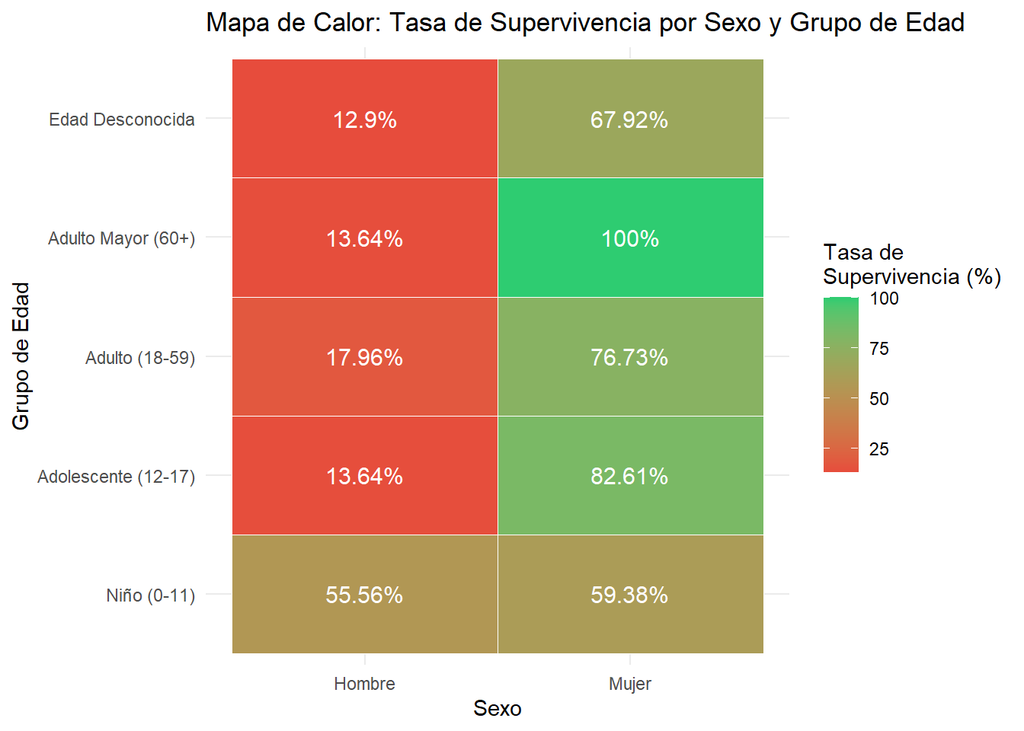

```r
# Heatmap de supervivencia
ggplot(analisis_combinado, aes(x = Sexo, y = Grupo_Edad, fill = Tasa_Supervivencia)) +
  geom_tile(color = "white") +
  geom_text(aes(label = paste0(Tasa_Supervivencia, "%")), color = "white", size = 4) +
  scale_fill_gradient(low = "#e74c3c", high = "#2ecc71", name = "Tasa de\nSupervivencia (%)") +
  labs(title = "Mapa de Calor: Tasa de Supervivencia por Sexo y Grupo de Edad",
       x = "Sexo", y = "Grupo de Edad") +
  theme_minimal()
```

```r
# Estadísticas de edad por grupo de supervivencia
estadisticas_edad_superv <- df %>%
  group_by(Sobrevivio) %>%
  summarise(
    n = n(),
    Media_Edad = mean(Edad, na.rm = TRUE),
    Mediana_Edad = median(Edad, na.rm = TRUE),
    SD_Edad = sd(Edad, na.rm = TRUE),
    Min_Edad = min(Edad, na.rm = TRUE),
    Max_Edad = max(Edad, na.rm = TRUE),
    .groups = 'drop'
  )

cat("Estadísticas de Edad por Estado de Supervivencia:\n")
```

```
## Estadísticas de Edad por Estado de Supervivencia:
```

```r
estadisticas_edad_superv %>% kable(digits = 2) %>% kable_styling()
```

| Sobrevivio | n | Media_Edad | Mediana_Edad | SD_Edad | Min_Edad | Max_Edad |
| --- | --- | --- | --- | --- | --- | --- |
| No | 549 | 30.63 | 28 | 14.17 | 1.00 | 74 |
| Sí | 342 | 28.34 | 28 | 14.95 | 0.42 | 80 |

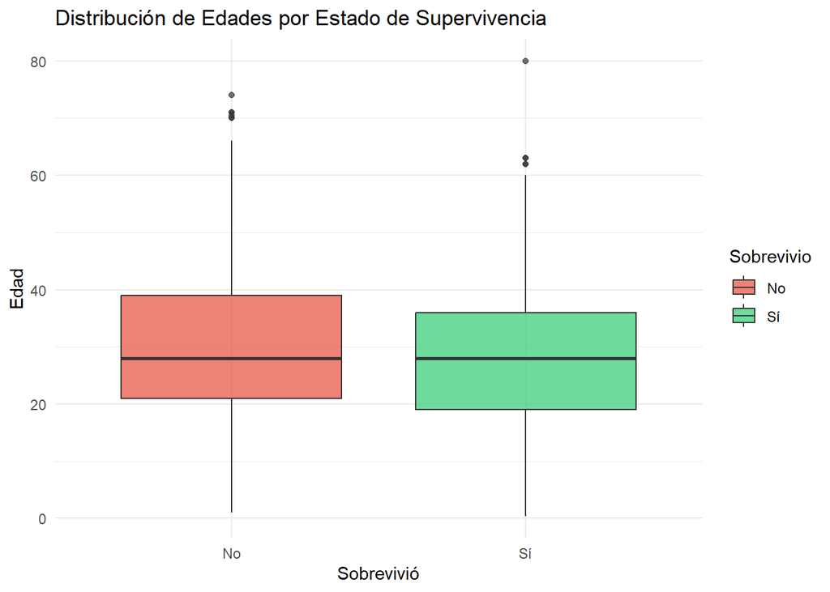

```r
# Boxplot de edades por supervivencia
ggplot(df, aes(x = Sobrevivio, y = Edad, fill = Sobrevivio)) +
  geom_boxplot(alpha = 0.7) +
  labs(title = "Distribución de Edades por Estado de Supervivencia",
       x = "Sobrevivió", y = "Edad") +
  theme_minimal() +
  scale_fill_manual(values = c("No" = "#e74c3c", "Sí" = "#2ecc71"))
```

## 5. Conclusión

El análisis estadístico del Titanic confirma de manera contundente que el género fue el factor determinante en la supervivencia, validando históricamente la aplicación del protocolo “mujeres y niños primero”. Las mujeres mostraron una tasa de supervivencia del 74.20% frente al 18.89% de los hombres, una brecha del 55.31% que revela la primacía del género sobre cualquier otra consideración demográfica. Si bien los niños fueron efectivamente protegidos (57.35% de supervivencia), el análisis combinado demostró que esta protección operaba de forma secundaria al privilegio femenino, observándose que las mujeres de todos los grupos etarios -incluyendo el 100% de las adultas mayores- mantuvieron tasas de supervivencia consistentemente altas. Estos patrones no solo cuantifican por primera vez la magnitud de las disparidades en el rescate, sino que exponen las jerarquías sociales profundamente arraigadas en la época Edwardiana, donde el valor percibido de una vida estaba determinado primordialmente por el género, incluso en circunstancias extremas de vida o muerte. El Titanic representa así un testimonio estadístico invaluable sobre cómo las normas sociales pueden traducirse en patrones de supervivencia dramáticamente diferenciados durante crisis humanitarias.